# Mendelian Randomization Analysis: CSF Tau and AAOS

By Dr. Shea Andrews, generated on 2018-09-04

## Data sources

*CSF Tau* (Deming et al 2017): A GWAS of CSF Tau levels (pg/mL) was conducted in 3,146 participants. Participants were of Eurpean ancestry.

*Alzheimer’s Age of Onset Surivial* (Huang et al 2017): A GWAS of age of onset in LOAD was conducted in 14,406 AD case samples and 25,849 control samples from the IGAP using Cox proportional hazard regressions. Participants were of European ancestry, in cases the the average AAO was 74.8 and 61.7% were women, in controls the average AAE was 79.0 and 59.6% were women.

## Instrumental Vaibles

**LD Clumping:** For standard two sample MR it is important to ensure that the instruments for the exposure are independent. LD clumping can be performed using the data_clump function from the TwoSampleMR package, which uses EUR samples from the 1000 genomes project to estimate LD between SNPs and amonst SNPs that have and LD above a given threshold, only the SNP with the lowest p-value will be retained.

**Proxy SNPs:** Where SNPs were not available in the outcome GWAS, the EUR thousand genomes was queried to identified potential proxy SNPs that are in linkage disequilibrium (r2 > 0.8) of the missing SNP.

### CSF Tau

CSF Tau: 122 SNPs (Table 1) were assoicated with were associated with CSF Tau at p < 5e-6. After LD clumping, 111 of 122 SNPs were removed.

**Table 1:** Independent SNPS associated with CSF Tau

| SNP | CHR | POS | Effect_allele | Non_Effect_allele | EAF | Beta | SE | P | r2 | N |
| --- | --- | --- | --- | --- | --- | --- | --- | --- | --- | --- |
| rs10800664 | 1 | 199959856 | T | C | 0.478395 | -0.02591 | 0.005653 | 4.770e-06 | 0.0003350373 | 3077 |
| rs4674842 | 2 | 224880514 | G | T | 0.238728 | -0.03081 | 0.006491 | 2.158e-06 | 0.0003450298 | 3095 |
| rs6770219 | 3 | 186194398 | T | C | 0.250970 | -0.03200 | 0.006982 | 4.804e-06 | 0.0003849914 | 2722 |
| rs35055419 | 3 | 190663557 | C | T | 0.363582 | 0.04004 | 0.006006 | 3.071e-11 | 0.0007419301 | 3091 |
| rs7737716 | 5 | 118217474 | T | C | 0.142270 | 0.04066 | 0.008535 | 1.984e-06 | 0.0004034862 | 3067 |
| rs13255475 | 8 | 121468076 | T | C | 0.343825 | -0.02793 | 0.006049 | 4.032e-06 | 0.0003519889 | 3089 |
| rs624290 | 9 | 3928115 | C | T | 0.114690 | -0.04421 | 0.009094 | 1.223e-06 | 0.0003969099 | 3108 |
| rs6859 | 19 | 45382034 | A | G | 0.423206 | 0.02894 | 0.005600 | 2.508e-07 | 0.0004088835 | 3108 |
| rs769449 | 19 | 45410002 | A | G | 0.108285 | 0.07821 | 0.006911 | 4.054e-29 | 0.0011812694 | 3087 |
| rs584007 | 19 | 45416478 | A | G | 0.366400 | -0.02801 | 0.005946 | 2.589e-06 | 0.0003642729 | 3100 |

[output cut: 1 more lines]

Of the the 11 SNPs associated with CSF Tau, 11 were available in the AAOS GWAS (Table 2).

**Table 2:** SNPS associated with CSF Tau avalible in AAOS GWAS

| SNP | CHR | POS | Effect_allele | Non_Effect_allele | EAF | Beta | SE | P | r2 | N |
| --- | --- | --- | --- | --- | --- | --- | --- | --- | --- | --- |
| rs10800664 | 1 | 199959856 | T | C | 0.4993 | -0.0262 | 0.0133 | 4.942e-02 | 3.432193e-04 | 40255 |
| rs4674842 | 2 | 224880514 | T | G | 0.7632 | 0.0086 | 0.0143 | 5.447e-01 | 2.673295e-05 | 40255 |
| rs6770219 | 3 | 186194398 | T | C | 0.2440 | 0.0044 | 0.0156 | 7.770e-01 | 7.142446e-06 | 40255 |
| rs35055419 | 3 | 190663557 | T | C | 0.6368 | -0.0025 | 0.0203 | 9.037e-01 | 2.891072e-06 | 40255 |
| rs7737716 | 5 | 118217474 | T | C | 0.1276 | -0.0062 | 0.0183 | 7.323e-01 | 8.558146e-06 | 40255 |
| rs13255475 | 8 | 121468076 | T | C | 0.3172 | -0.0060 | 0.0130 | 6.481e-01 | 1.559406e-05 | 40255 |
| rs624290 | 9 | 3928115 | T | C | 0.9013 | 0.0676 | 0.0204 | 9.440e-04 | 8.130363e-04 | 40255 |
| rs6859 | 19 | 45382034 | A | G | 0.4633 | 0.2250 | 0.0193 | 1.853e-31 | 2.517613e-02 | 40255 |
| rs769449 | 19 | 45410002 | A | G | 0.1641 | 0.7200 | 0.0329 | 6.810e-106 | 1.422191e-01 | 40255 |
| rs584007 | 19 | 45416478 | A | G | 0.3403 | -0.2252 | 0.0286 | 3.161e-15 | 2.277064e-02 | 40255 |

[output cut: 1 more lines]

### AAOS

AAOS: 570 SNPs (Table 3) were assoicated with were associated with AAOS at p < 5e-6. After LD clumping, 511 of 570 SNPs were removed.

**Table 3:** Independent SNPS associated with AAOS

| SNP | CHR | POS | Effect_allele | Non_Effect_allele | EAF | Beta | SE | P | r2 | N |
| --- | --- | --- | --- | --- | --- | --- | --- | --- | --- | --- |
| rs2649062 | 1 | 5799177 | A | G | 0.6808 | -0.0652 | 0.0131 | 6.120e-07 | 0.001847599 | 40255 |
| rs4662080 | 1 | 14363419 | T | C | 0.6649 | 0.1421 | 0.0296 | 1.586e-06 | 0.008998061 | 40255 |
| rs10919252 | 1 | 169802956 | C | G | 0.6725 | -0.0975 | 0.0198 | 8.182e-07 | 0.004187384 | 40255 |
| rs6701713 | 1 | 207786289 | A | G | 0.2017 | 0.0709 | 0.0146 | 1.184e-06 | 0.001618805 | 40255 |
| rs6718282 | 2 | 18039651 | A | G | 0.0440 | -0.1421 | 0.0308 | 3.840e-06 | 0.001698747 | 40255 |
| rs12615104 | 2 | 109820829 | T | C | 0.7434 | 0.1057 | 0.0221 | 1.829e-06 | 0.004262449 | 40255 |
| rs111906619 | 2 | 127789085 | T | C | 0.0709 | 0.1268 | 0.0256 | 7.088e-07 | 0.002118250 | 40255 |
| rs10194375 | 2 | 127839781 | A | C | 0.3494 | 0.0588 | 0.0126 | 3.342e-06 | 0.001571888 | 40255 |
| rs6431219 | 2 | 127862133 | T | C | 0.4163 | 0.0774 | 0.0124 | 3.897e-10 | 0.002911441 | 40255 |
| rs13032148 | 2 | 127865100 | A | G | 0.3293 | 0.0820 | 0.0144 | 1.125e-08 | 0.002970146 | 40255 |

[output cut: 49 more lines]

**Table 4:** SNPS associated with AAOS avalible in CSF Tau GWAS

| SNP | CHR | POS | Effect_allele | Non_Effect_allele | EAF | Beta | SE | P | r2 | N |
| --- | --- | --- | --- | --- | --- | --- | --- | --- | --- | --- |
| rs2649062 | 1 | 5799177 | G | A | 0.3297810 | 0.0005743 | 0.006568 | 9.303e-01 | 1.457975e-07 | 2700 |
| rs10919252 | 1 | 169802956 | G | C | 0.3120570 | -0.0040550 | 0.005919 | 4.934e-01 | 7.059893e-06 | 3104 |
| rs6701713 | 1 | 207786289 | A | G | 0.1919620 | 0.0143000 | 0.006969 | 4.022e-02 | 6.343795e-05 | 3107 |
| rs6718282 | 2 | 18039651 | A | G | 0.0663228 | -0.0033190 | 0.013260 | 8.023e-01 | 1.364282e-06 | 3086 |
| rs12615104 | 2 | 109820829 | C | T | 0.2917920 | 0.0009067 | 0.006517 | 8.894e-01 | 3.397750e-07 | 3067 |
| rs111906619 | 2 | 127789085 | T | C | 0.0705574 | 0.0155700 | 0.011270 | 1.672e-01 | 3.179599e-05 | 3030 |
| rs10194375 | 2 | 127839781 | A | C | 0.3383580 | 0.0115200 | 0.006023 | 5.577e-02 | 5.942025e-05 | 3108 |
| rs6431219 | 2 | 127862133 | T | C | 0.3964120 | -0.0019360 | 0.005696 | 7.340e-01 | 1.793610e-06 | 3071 |
| rs13032148 | 2 | 127865100 | A | G | 0.3220820 | 0.0125700 | 0.005923 | 3.389e-02 | 6.899922e-05 | 3055 |
| rs116341973 | 3 | 63462893 | G | A | 0.0207884 | 0.0262100 | 0.018110 | 1.478e-01 | 2.796802e-05 | 3101 |

[output cut: 31 more lines]

## Data harmonization

Harmonize the exposure and outcome datasets so that the effect of a SNP on the exposure and the effect of that SNP on the outcome correspond to the same allele. The harmonise_data function from the TwoSampleMR package can be used to perform the harmonization step, by default it try’s to infer the forward strand alleles using allele frequency information. EAF were not availbe in the IGAP summary statisitics, as such the allele frequencies reported in the AAOS anaylsis were used.

### Exposure: CSF Tau ~ Outcome: AAOS

**Table 5:** Harmonized and LOAD datasets

| SNP | effect_allele.exposure | other_allele.exposure | effect_allele.outcome | other_allele.outcome | beta.exposure | beta.outcome | eaf.exposure | eaf.outcome | se.outcome | pval.outcome | se.exposure | pval.exposure |
| --- | --- | --- | --- | --- | --- | --- | --- | --- | --- | --- | --- | --- |
| rs10800664 | T | C | T | C | -0.02591 | -0.0262 | 0.478395 | 0.4993 | 0.0133 | 4.942e-02 | 0.005653 | 4.770e-06 |
| rs13255475 | T | C | T | C | -0.02793 | -0.0060 | 0.343825 | 0.3172 | 0.0130 | 6.481e-01 | 0.006049 | 4.032e-06 |
| rs1513737 | T | C | T | C | 0.02597 | -0.0074 | 0.462242 | 0.4701 | 0.0189 | 6.955e-01 | 0.005620 | 3.986e-06 |
| rs35055419 | C | T | C | T | 0.04004 | 0.0025 | 0.363582 | 0.3632 | 0.0203 | 9.037e-01 | 0.006006 | 3.071e-11 |
| rs4674842 | G | T | G | T | -0.03081 | -0.0086 | 0.238728 | 0.2368 | 0.0143 | 5.447e-01 | 0.006491 | 2.158e-06 |
| rs584007 | A | G | A | G | -0.02801 | -0.2252 | 0.366400 | 0.3403 | 0.0286 | 3.161e-15 | 0.005946 | 2.589e-06 |
| rs624290 | C | T | C | T | -0.04421 | -0.0676 | 0.114690 | 0.0987 | 0.0204 | 9.440e-04 | 0.009094 | 1.223e-06 |
| rs6770219 | T | C | T | C | -0.03200 | 0.0044 | 0.250970 | 0.2440 | 0.0156 | 7.770e-01 | 0.006982 | 4.804e-06 |
| rs6859 | A | G | A | G | 0.02894 | 0.2250 | 0.423206 | 0.4633 | 0.0193 | 1.853e-31 | 0.005600 | 2.508e-07 |
| rs769449 | A | G | A | G | 0.07821 | 0.7200 | 0.108285 | 0.1641 | 0.0329 | 6.810e-106 | 0.006911 | 4.054e-29 |

[output cut: 1 more lines]

### Exposure: AAOS ~ Outcome: CSF Tau

**Table 5:** Harmonized and LOAD datasets

| SNP | effect_allele.exposure | other_allele.exposure | effect_allele.outcome | other_allele.outcome | beta.exposure | beta.outcome | eaf.exposure | eaf.outcome | se.outcome | pval.outcome | se.exposure | pval.exposure |
| --- | --- | --- | --- | --- | --- | --- | --- | --- | --- | --- | --- | --- |
| rs10194375 | A | C | A | C | 0.0588 | 0.0115200 | 0.3494 | 0.3383580 | 0.006023 | 5.577e-02 | 0.0126 | 3.342e-06 |
| rs1043441 | T | C | T | C | -0.0639 | 0.0133600 | 0.2893 | 0.2893440 | 0.006205 | 3.143e-02 | 0.0135 | 2.110e-06 |
| rs10919252 | C | G | C | G | -0.0975 | 0.0040550 | 0.6725 | 0.6879430 | 0.005919 | 4.934e-01 | 0.0198 | 8.182e-07 |
| rs1118069 | A | T | A | T | -0.1012 | 0.0009011 | 0.2805 | 0.2688480 | 0.006172 | 8.839e-01 | 0.0216 | 2.693e-06 |
| rs111906619 | T | C | T | C | 0.1268 | 0.0155700 | 0.0709 | 0.0705574 | 0.011270 | 1.672e-01 | 0.0256 | 7.088e-07 |
| rs11218343 | T | C | T | C | 0.1653 | 0.0119000 | 0.9605 | 0.9559285 | 0.013790 | 3.884e-01 | 0.0329 | 5.148e-07 |
| rs116341973 | A | G | A | G | -0.2057 | -0.0262100 | 0.9773 | 0.9792116 | 0.018110 | 1.478e-01 | 0.0399 | 2.478e-07 |
| rs11665676 | T | C | T | C | -0.2168 | -0.0287100 | 0.0456 | 0.0558670 | 0.014800 | 5.255e-02 | 0.0323 | 2.049e-11 |
| rs117201713 | C | G | C | G | 0.2125 | -0.0203900 | 0.0408 | 0.0330767 | 0.015940 | 2.007e-01 | 0.0456 | 3.120e-06 |
| rs12153819 | T | C | T | C | -0.1092 | -0.0044090 | 0.1018 | 0.1161840 | 0.008802 | 6.165e-01 | 0.0235 | 3.291e-06 |

[output cut: 31 more lines]

## Mendelian Randomization Analysis

### Exposure: CSF Tau ~ Outcome: AAOS

Figure 1 illustrates the SNP-specific associations with CSF Tau versus the association in AAOS.

[figure not shown]

Figure 2 and Table 1 shows the SNP-specific effects and overall IVW, weighted median and Egger regression causal estimates of genetically predicted CSF Tau on AAOS.

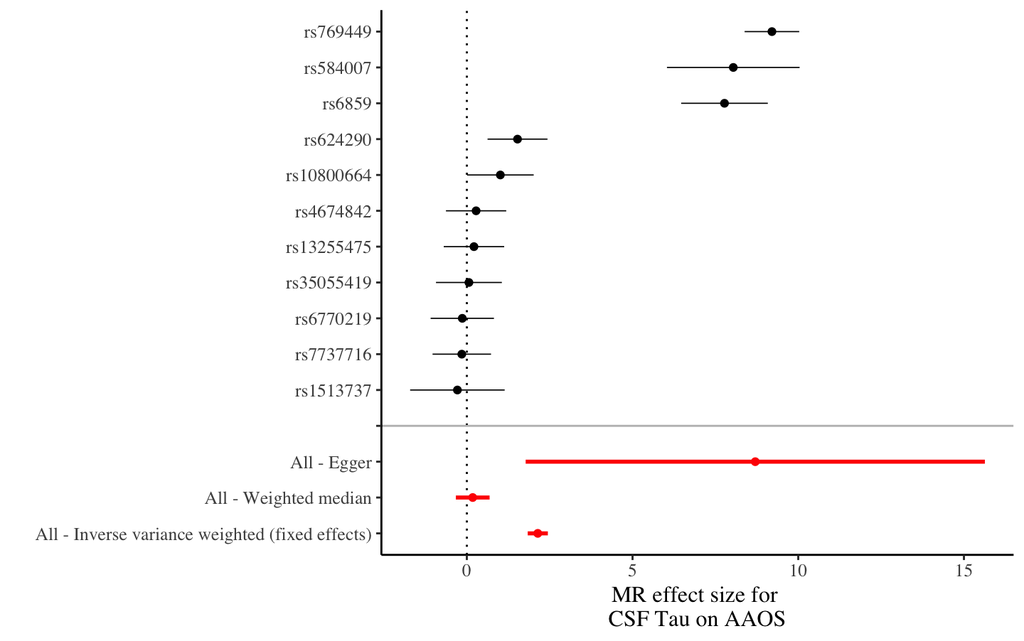

Fig. 2: Forrest plot of Wald ratios and 95% CIs for SNP-specific and overall IVW, Weighted median and Egger associations

**Table 1:** MR estimates for CSF Tau, on AAOS

|  | SNP | b | se | p |
| --- | --- | --- | --- | --- |
| 1 | rs10800664 | 1.01119259 | 0.5133153 | 4.884699e-02 |
| 2 | rs13255475 | 0.21482277 | 0.4654493 | 6.444123e-01 |
| 3 | rs1513737 | -0.28494417 | 0.7277628 | 6.954023e-01 |
| 4 | rs35055419 | 0.06243756 | 0.5069930 | 9.019862e-01 |
| 5 | rs4674842 | 0.27913015 | 0.4641350 | 5.475745e-01 |
| 6 | rs584007 | 8.03998572 | 1.0210639 | 3.431334e-15 |
| 7 | rs624290 | 1.52906582 | 0.4614341 | 9.206184e-04 |
| 8 | rs6770219 | -0.13750000 | 0.4875000 | 7.779042e-01 |
| 9 | rs6859 | 7.77470629 | 0.6668970 | 2.088152e-31 |
| 10 | rs769449 | 9.20598389 | 0.4206623 | 3.650032e-106 |

[output cut: 4 more lines]

Figure 3 shows a funnel plot to detect pleiotropy and Table 2 show the results of Cochrans Q heterogeneity test to assess for the presence of pleiotropy.

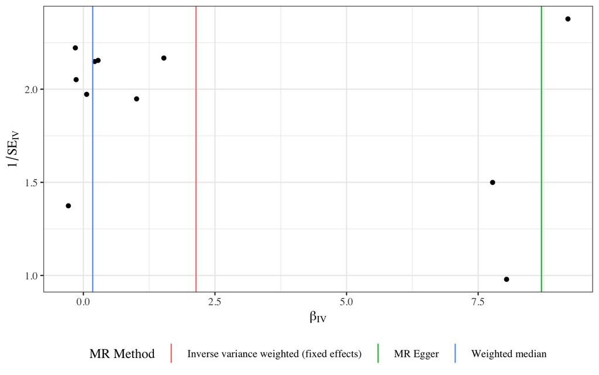

Fig. 3: Funnel plot of the MR causal estimates against their precession

**Table 2:** Heterogenity tests for CSF Tau on AAOS

| id.exposure | id.outcome | outcome | exposure | method | Q | Q_df | Q_pval |
| --- | --- | --- | --- | --- | --- | --- | --- |
| KZ30kT | jOsKOs | aaos | tau | MR Egger | 355.1545 | 9 | 4.954322e-71 |
| KZ30kT | jOsKOs | aaos | tau | Inverse variance weighted | 502.3613 | 10 | 1.381360e-101 |

**Table 3:** Test for directional pleitropy for CSF Tau on AAOS

| id.exposure | id.outcome | outcome | exposure | egger_intercept | se | pval |
| --- | --- | --- | --- | --- | --- | --- |
| KZ30kT | jOsKOs | aaos | tau | -0.2318447 | 0.1200386 | 0.0854778 |

### Exposure: AAOS ~ Outcome: CSF Tau

Figure 4 illustrates the SNP-specific associations with AAOS versus the association in CSF Tau.

[figure not shown]

Figure 5 and Table 4 shows the SNP-specific effects and overall IVW, weighted median and Egger regression causal estimates of genetically predicted AAOS on CSF Tau.

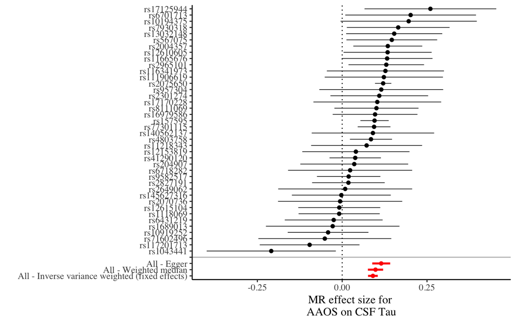

Fig. 5: Forrest plot of Wald ratios and 95% CIs for SNP-specific and overall IVW, Weighted median and Egger associations

**Table 4:** MR estimates for AAOS, on CSF Tau

|  | SNP | b | se | p |
| --- | --- | --- | --- | --- |
| 1 | rs10194375 | 0.195918367 | 0.102431973 | 5.579055e-02 |
| 2 | rs1043441 | -0.209076682 | 0.097104851 | 3.131064e-02 |
| 3 | rs10919252 | -0.041589744 | 0.060707692 | 4.932922e-01 |
| 4 | rs1118069 | -0.008904150 | 0.060988142 | 8.839229e-01 |
| 5 | rs111906619 | 0.122791798 | 0.088880126 | 1.671118e-01 |
| 6 | rs11218343 | 0.071990321 | 0.083424077 | 3.881682e-01 |
| 7 | rs116341973 | 0.127418571 | 0.088040836 | 1.478222e-01 |
| 8 | rs11665676 | 0.132426199 | 0.068265683 | 5.239612e-02 |
| 9 | rs117201713 | -0.095952941 | 0.075011765 | 2.008365e-01 |
| 10 | rs12153819 | 0.040375458 | 0.080604396 | 6.164352e-01 |

[output cut: 33 more lines]

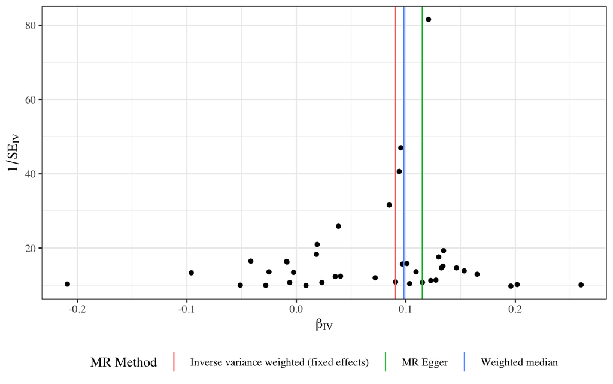

Fig. 6: Funnel plot of the MR causal estimates against their precession

**Table 5:** Heterogenity tests for AAOS and CSF Tau

| exposure | outcome | method | Q | Q_df | Q_pval |
| --- | --- | --- | --- | --- | --- |
| aaos | tau | MR Egger | 51.08167 | 38 | 0.07621993 |
| aaos | tau | Inverse variance weighted | 58.34281 | 39 | 0.02388951 |

**Table 6:** Test for directional pleitropy for AAOS and CSF Tau

| id.exposure | id.outcome | outcome | exposure | egger_intercept | se | pval |
| --- | --- | --- | --- | --- | --- | --- |
| G2RiKC | FCZBDT | tau | aaos | -0.005101452 | 0.002194987 | 0.02556325 |

## MR analysis results

| exposure | outcome | method | nsnp | b | se | pval | Signif |
| --- | --- | --- | --- | --- | --- | --- | --- |
| tau | aaos | IVW | 11 | 2.14047032 | 0.155171579 | 2.761375e-43 | *** |
| tau | aaos | Weighted median | 11 | 0.17745826 | 0.238474046 | 4.567913e-01 |  |
| tau | aaos | MR Egger | 11 | 8.70318165 | 3.534924078 | 3.603688e-02 | * |
| aaos | tau | IVW | 40 | 0.09059331 | 0.007320008 | 3.519470e-35 | *** |
| aaos | tau | Weighted median | 40 | 0.09819612 | 0.012089444 | 4.567998e-16 | *** |
| aaos | tau | MR Egger | 40 | 0.11499441 | 0.013500275 | 2.415541e-10 | *** |